# What makes a Hollywood film successful?

Joanna Andari, Karim Awad, Jiye Ren, Nirbhay Sharma, Qiuyue Zhang, Xiaoyan Zhou

8 October 2017

[output not shown]

[output not shown]

## Section 1: Introduction

Outside of India, the US continues to lead the way in producing a substantial volume of films, accounting for an estimated US$10.7bn in box office revenues in 2016[^2]. Yet in contrast to Indian films, which principally serve a domestic audience, Hollywood films benefit from a global distribution network. This results in films having to cater for different audiences in different countries, overcoming issues varying from political censorship through to cultural sensitivities, to maximise their appeal and potential commercial success.

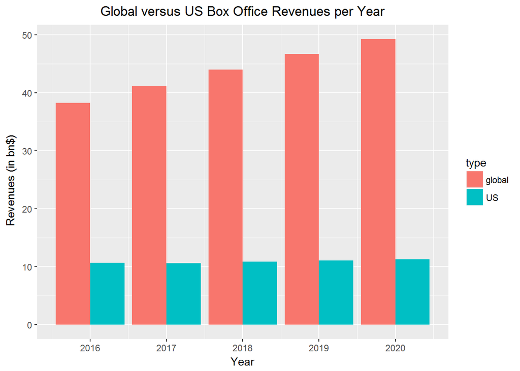

Although continued growth in China and India are likely to dominate global box office revenue growth until 2020, Hollywood is likely to remain a bellweather of judging a film’s global success, given its wide audience base. With that in mind, are there factors that can help predict a film’s popularity, and with that, guide future decisions on the types of films produced? In turn, can this better inform investors (and if applicable, governments) on potential risks involved with supporting particular projects?

This report seeks to examine a sample of movie data pulled from IMDB data between 2011-16, concentrating on the US given its role in influencing the wider film industry. This will seek to understand how we should measure popularity, focusing on 2011-15 data, before devising a regression model that can help predict popularity. We will then test its capacity to predict 2016 trends, before noting the limitations of our work, and areas for further development.

## Section 2: Data sampling and cleaning

The data compiled for this project/analysis is obtained from 2 different datasets:

- **IMDB Movie Dataset**
- **Oscar Awards Dataset**

Given the lack of data on several variables, we have been creative with identifying particular financial and film-related characteristics. For instance, we have derived an ROI variable based on ticket sales divided by a film’s budget, to gauge the box office success of films. We have also derived genre dummies, based on the number of times a particular genre is mentioned for each film, to determine whether specific types of films are more popular than others. Finally, in an effort to gauge actor and director popularity, we have derived actor dummies for the lead and two supporting actors, and a director dummy, both based on the number of times they appear within our sample. We have complemented this with separately pulling up Oscar data on both areas, as we recognise audience preferences are likely to change rather slowly over time (e.g. favourite actor, etc).

We discuss the merits of this approach throughout the report, along with commenting about potential limitations and improvements within Section 6.

## Section 3: How do we measure a film’s popularity?

### What metrics should we use to determine our dependent variable?

Determining what variable should represent popularity, itself a subjective quality, gives rise to several potential proxy variables. These can be divided between those that are financially driven relative to social media metrics, of which we consider each in turn, arriving at five possible variables.

An obvious proxy would be revenues, should we determine this a valid measure of commercial success. Contrary to the thoughts of those “voting with their wallets”, this is not entirely a straightforward metric. A limitation of the data available is we are only able to track global box-office ticket sales, rather than all associated revenues. This ignores digital sales from streaming, DVD sales, and any other merchandise or commercial agreements (e.g. in-film advertising).

An example of this shortcoming would be the motion picture, “The Interview”. Although extreme given the political sensitivities with North Korea, which led to a limited global release, “The Interview grossed US$40m in digital rentals…and earned an additional US$11.2m worldwide at the box office on a US$44m budget[^3]”. By relying on box office revenues alone, we may not get a complete view on how commercially successful a film has been. This is something we discuss further as a limitation within our work, but which we do not explore further.

A second issue is whether a low grossing film is still a success, relative to its underlying budget? This may be more applicable to arthouse films, rather than a typical Hollywood blockbuster, but is something we are able to condition against by examining a film’s return on investment; defined by its box office revenues divided by its total budget.

Social media provides us with three relevant metrics. The first surrounds the number of facebook likes a film has received. Although a singular expression of popularity, this provides some indication of fan reaction, premised on any “likes” resulting from watching the film, as opposed to being based on trailers or other promotional material. We are mindful this may not be entirely accurate, as we do not know at which point this data was collected (e.g. how many days / weeks after the film was released in the US, and how the latter is likely to vary by geography).

The remaining two metrics concern IMDB scores, and the number of votes received. IMDB scores should provide a direct measure of popularity, with our initial assumption based on this most likely to be normally distributed (i.e. this theoretically should capture a broad range of views between a ranking of 0-10). The number of users may also help quantify the depth of support, and depending on the distribution of IMDB scores, represent a useful proxy for capturing popularity.

We recognise that social media metrics will be lagged indicators of a film’s success. Hence, we are likely to depend upon a commercial variable to project future success, although social media can help by identifying film types that are likely to prove popular, which may form the basis of choosing future films to invest within.

### Descriptive analysis

We produce boxplots and density graphs of the five variables above, along with budget to provide a sense-check. These can all separately be found in the appendices.

We summarises some of the key descriptive findings of these graphs, along with illustrating the results of our ROI boxplot (limited to returns up to 5.0x) and IMDB density graph:

```r
summary_data <- data11_15 %>% select(gross, budget, num_voted_users, imdb_score, movie_facebook_likes, return)
summary_data = as.data.frame(describe(summary_data, quant = c(.25,.75)))
summary_data = summary_data[ , !(names(summary_data) %in% c("vars","n","mad","range","kurtosis","se","trimmed"))]
rownames(summary_data) <- c("Gross Revenue","Budget","Number of voted users","IMDB Score","Movie's Facebook Likes","ROI")
colnames(summary_data) <- c("Mean","Stan. Dev.","Median","Min","Max","Skew","1st Quar","3rd Quar")
kable(summary_data)
```

|  | Mean | Stan. Dev. | Median | Min | Max | Skew | 1st Quar | 3rd Quar |
| --- | --- | --- | --- | --- | --- | --- | --- | --- |
| Gross Revenue | 8.076585e+07 | 8.952923e+07 | 52145640.000 | 1332.0 | 652177271.00 | 2.3720550 | 23421332.00 | 1.033075e+08 |
| Budget | 5.953187e+07 | 5.841149e+07 | 40000000.000 | 9000.0 | 263700000.00 | 1.2790274 | 16000000.00 | 8.500000e+07 |
| Number of voted users | 1.564911e+05 | 1.547430e+05 | 104812.500 | 22.0 | 1144337.00 | 2.2574086 | 54627.75 | 2.028208e+05 |
| IMDB Score | 6.591968e+00 | 8.871856e-01 | 6.700 | 1.6 | 8.60 | -0.8269727 | 6.10 | 7.200000e+00 |
| Movie’s Facebook Likes | 3.819202e+04 | 3.580031e+04 | 27000.000 | 44.0 | 349000.00 | 2.6835595 | 15000.00 | 4.775000e+04 |
| ROI | 2.341466e+00 | 3.949516e+00 | 1.225 | 0.0 | 53.25 | 6.4814016 | 0.68 | 2.435000e+00 |

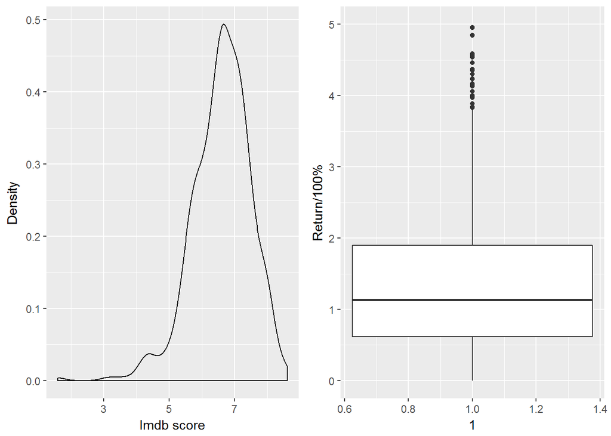

```r
imdbden <- ggplot(data=data11_15)+geom_density(aes(x=(imdb_score)))+xlab("Imdb score")+ylab("Density")
roibox <- ggplot(data=data11_15)+geom_boxplot(aes(x=1, y=return)) + ylim(0,5)+ylab("Return/100%")
grid.arrange(imdbden, roibox,  ncol=2)
```

There are several intriguing observations. Firstly we observe that all our variables except IMDB scores are positively skewed, with the latter negatively skewed. This confounds our earlier thoughts on IMDB scores being normally distributed. With a median score of 6.7, this implies fans are likely to respond with favourable views, especially with our 1st and 3rd quartile scores between 6.1 and 7.2 respectively. More generally, we will need to proceed with any regression analysis carefully (see further comments below).

Examining our financial metrics, our ROI variable suggests a median film will make a return of 1.2x, although this engenders significant volatility, reflected within our wide range, and a standard deviation that would imply a negative mean on the downside. Ignoring the latter, this volatility seems consistent with the level of risk associated with producing films, with properties mimicking a financial option (e.g. an upfront payment with no assurance of exercise), given the uncertainty in audience receptiveness.

This uncertainty is reinforced in the range of revenue figures, and corresponding budget figures respectively. With revenue, this volatility is likely to be more pronounced in practice, as our metric only focuses on box office tickets. These figures imply a median film will have a budget of US$40m and be expected to generate box office revenues of US$52m, broadly consistent with our ROI estimate above.

Our last observation is the comparative depth of number of IMDB votes relative to facebook likes. As alluded towards earlier, it is unclear how such facebook data has been collected, nor the interval between the film’s release and data collection. The latter is equally applicable to IMDB scores; however, given the negative skew with this statistic, the higher number of votes may prove a more desirable proxy in gauging popularity. We shall seek to confirm this by testing how these variables correlate with each other, to guide our final choice on our dependent variables.

### Correlation analysis

|  | imdb_score | movie_facebook_likes | gross | return | budget | num_voted_users |
| --- | --- | --- | --- | --- | --- | --- |
| imdb_score | 1.00 | 0.47 | 0.29 | -0.07 | 0.15 | 0.53 |
| movie_facebook_likes | 0.47 | 1.00 | 0.53 | 0.01 | 0.38 | 0.80 |
| gross | 0.29 | 0.53 | 1.00 | 0.04 | 0.68 | 0.66 |
| return | -0.07 | 0.01 | 0.04 | 1.00 | -0.25 | -0.03 |
| budget | 0.15 | 0.38 | 0.68 | -0.25 | 1.00 | 0.52 |
| num_voted_users | 0.53 | 0.80 | 0.66 | -0.03 | 0.52 | 1.00 |

|  | imdb_score | movie_facebook_likes | gross | return | budget | num_voted_users |
| --- | --- | --- | --- | --- | --- | --- |
| imdb_score | NA | 0.0000000 | 0.0000000 | 0.1464951 | 0.0007002 | 0.0000000 |
| movie_facebook_likes | 0.0000000 | NA | 0.0000000 | 0.8599276 | 0.0000000 | 0.0000000 |
| gross | 0.0000000 | 0.0000000 | NA | 0.3643228 | 0.0000000 | 0.0000000 |
| return | 0.1464951 | 0.8599276 | 0.3643228 | NA | 0.0000000 | 0.5170522 |
| budget | 0.0007002 | 0.0000000 | 0.0000000 | 0.0000000 | NA | 0.0000000 |
| num_voted_users | 0.0000000 | 0.0000000 | 0.0000000 | 0.5170522 | 0.0000000 | NA |

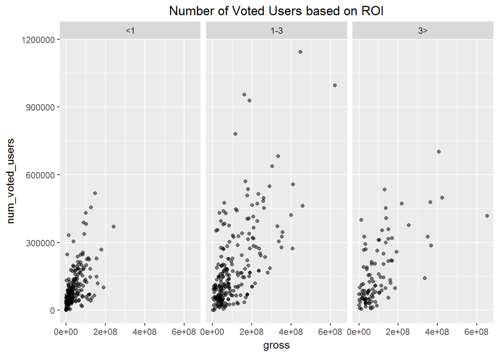

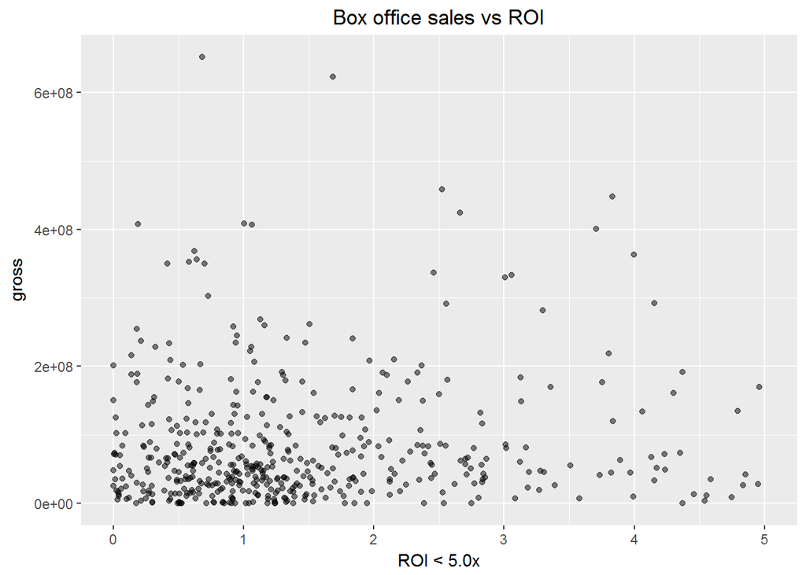

In contrast to revenues, we do not consider ROI as suitable for further analysis as a dependent variable. We produced two scatter plots to confirm this finding. The first, which segregates returns, shows no underlying change on the positive relationship between box office revenue and IMDB votes. In other words, each type of return appears just as likely as we vary IMDB votes and sales achieved. This is more apparent when we produce a scatterplot of revenues over returns, where no relationship appears apparent between high-grossing and small box office sales. These results are surprising, as we expected some pattern to emerge, be it positive or negative correlation (e.g. either films grossing higher box office sales generate larger returns, or small films performing far better compared to large films that lose money due to higher costs). Neither is evident, of which we comment further in section 6, as we’d expect ROI to be a significant factor in measuring success.

Revenues as a financial metric has demonstrated the positive relationships we expected to see amongst social media (e.g. facebook likes and number of voted users), indicating that expressions of support tend to correspond with higher box office revenues (i.e. people go to the cinema). We do note the more weak positive correlation with IMDB scores (esp. relative to number of voting IMDB users), which we suspect is a function of the latter’s negative skew, although given the strong correlation with budget, this partly offsets these concerns. The latter relationship would correspond well with blockbusters generating higher revenues, conditioned on budgets that can support the hiring of better actors, and increased marketing / promotional spend.

Equally, we observe a more positive correlation between number of voted users, against other metrics, relative to both IMDB scores and facebook likes. This warrants reappraising this variable, as it may represent a better proxy relative to IMDB scores themselves. From our descriptive analysis section above, we note a strong negative skew in IMDB scores, suggesting that those voting are likely to be fans conveying their support for a film, rather than providing a balanced critique. Therefore the number of IMDB votes may better represent the strength of popularity enjoyed by a particular movie. However, we are conscious of the possibility that not all these votes will be conveying the same numerical grade, nor the potential for duplicate votes to be included in any final score.

In sum, we believe examining both revenue and the number of IMDB votes separately, can help better inform our perspective on what constitutes a successful film. Yet both of these dependent variables demonstrate strong positive skew, which could bias any parameter estimate, and impact on variance calculations, affecting the accuracy of any t-statistic. Performing multiple regression analysis using OLS as it stands is unlikely to be appropriate. Remedies available are to perform regression using a GLS-based approach, or to transform our variables to resemble a normal distribution. Although extending beyond the scope of this assignment, we transform both our revenue and number of votes variables by natural logs raised to the power of 6 and 4 respectively (see below). As these transformations will generate beta estimates which are not intuitive, we conduct our regressions without these adjustment, altering our y-variable at the end to get a better understanding of our parameters and overall adjusted R-squared.

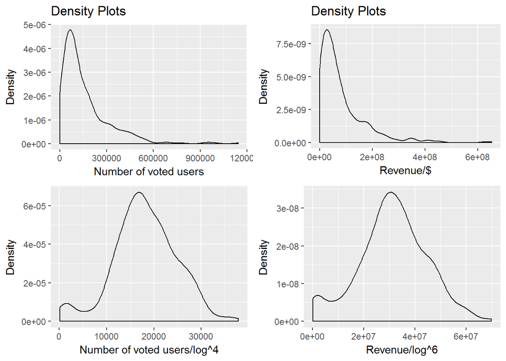

## Section 4: Regression Analysis

### Social media: Number of IMDB votes

|  | *Dependent variable:* |  |  |  |  |  |  |  |  |  |
| --- | --- | --- | --- | --- | --- | --- | --- | --- | --- | --- |
|  | num_voted_users |  |  |  |  |  |  |  |  | log4numvoted_users |
|  | (1) | (2) | (3) | (4) | (5) | (6) | (7) | (8) | (9) | (10) |
| gross | 0.001 | 0.001 | 0.001 | 0.001 | 0.001 | 0.001 | 0.001 | 0.001 | 0.001 | 0.00005 |
|  | t = 19.585*** | t = 17.536*** | t = 18.998*** | t = 19.037*** | t = 16.128*** | t = 14.494*** | t = 15.233*** | t = 15.498*** | t = 19.919*** | t = 16.348*** |
| actor1_occurence |  | 13,409.810 | 11,253.730 | 10,844.050 | 4,545.940 | -26.233 | 490.505 | 817.328 |  |  |
|  |  | t = 2.267** | t = 1.992** | t = 1.988** | t = 0.902 | t = -0.005 | t = 0.099 | t = 0.167 |  |  |
| actor2_occurence |  | -17,065.530 |  |  |  |  |  |  |  |  |
|  |  | t = -1.249 |  |  |  |  |  |  |  |  |
| actor3_occurence |  | 5,167.142 |  |  |  |  |  |  |  |  |
|  |  | t = 0.945 |  |  |  |  |  |  |  |  |
| director_occurence |  |  | -18,104.070 |  |  |  |  |  |  |  |
|  |  |  | t = -0.853 |  |  |  |  |  |  |  |
| movie_oscars |  |  |  | 29,663.330 |  |  |  |  |  |  |
|  |  |  |  | t = 1.353 |  |  |  |  |  |  |
| duration |  |  |  |  | 2,534.009 | 2,098.029 | 2,111.728 | 2,100.650 |  |  |
|  |  |  |  |  | t = 9.779*** | t = 7.366*** | t = 7.906*** | t = 7.898*** |  |  |
| actor_oscars |  |  |  | 61,136.170 | 40,819.340 | 39,984.920 | 40,584.820 | 39,749.860 | 54,371.880 | 2,152.065 |
|  |  |  |  | t = 5.790*** | t = 4.132*** | t = 4.106*** | t = 4.212*** | t = 4.156*** | t = 5.465*** | t = 4.560*** |
| actiondummy |  |  |  |  |  | 5,551.934 | 8,828.738 |  |  |  |
|  |  |  |  |  |  | t = 0.470 | t = 0.791 |  |  |  |
| adventuredummy |  |  |  |  |  | 13,855.150 |  |  |  |  |
|  |  |  |  |  |  | t = 1.050 |  |  |  |  |
| comedydummy |  |  |  |  |  | -693.482 |  |  |  |  |
|  |  |  |  |  |  | t = -0.061 |  |  |  |  |
| familydummy |  |  |  |  |  | -79,095.180 | -69,295.210 | -73,194.760 | -115,032.800 | -3,848.250 |
|  |  |  |  |  |  | t = -4.329*** | t = -4.408*** | t = -4.860*** | t = -7.715*** | t = -5.442*** |
| fantasydummy |  |  |  |  |  | 7,082.222 |  |  |  |  |
|  |  |  |  |  |  | t = 0.521 |  |  |  |  |
| horrordummy |  |  |  |  |  | 1,515.187 |  |  |  |  |
|  |  |  |  |  |  | t = 0.093 |  |  |  |  |
| romancedummy |  |  |  |  |  | 8,540.462 | 7,222.590 |  |  |  |
|  |  |  |  |  |  | t = 0.633 | t = 0.549 |  |  |  |
| scifidummy |  |  |  |  |  | 37,036.080 | 38,764.240 | 41,433.760 | 39,309.540 | 1,817.534 |
|  |  |  |  |  |  | t = 2.752*** | t = 3.006*** | t = 3.350*** | t = 3.010*** | t = 2.934*** |
| thrillerdummy |  |  |  |  |  | 5,262.819 | 2,781.666 |  |  |  |
|  |  |  |  |  |  | t = 0.443 | t = 0.257 |  |  |  |
| Constant | 64,305.450 | 37,101.970 | 55,885.720 | 9,620.378 | -229,426.700 | -170,125.100 | -171,847.700 | -167,535.900 | 58,272.530 | 14,166.470 |
|  | t = 9.156*** | t = 0.861 | t = 1.154 | t = 0.426 | t = -7.142*** | t = -4.476*** | t = -5.056*** | t = -5.031*** | t = 8.677*** | t = 44.474*** |
| Observations | 498 | 498 | 498 | 498 | 498 | 498 | 498 | 498 | 498 | 498 |
| R<sup>2</sup> | 0.436 | 0.442 | 0.441 | 0.480 | 0.563 | 0.596 | 0.595 | 0.594 | 0.542 | 0.447 |
| Adjusted R<sup>2</sup> | 0.435 | 0.438 | 0.438 | 0.476 | 0.559 | 0.586 | 0.588 | 0.589 | 0.538 | 0.443 |
| Residual Std. Error | 116,319.400 (df = 496) | 116,016.800 (df = 493) | 115,997.400 (df = 494) | 112,018.700 (df = 493) | 102,706.000 (df = 493) | 99,621.440 (df = 484) | 99,385.370 (df = 488) | 99,182.840 (df = 491) | 105,156.500 (df = 493) | 4,987.700 (df = 493) |
| F Statistic | 383.577*** (df = 1; 496) | 97.793*** (df = 4; 493) | 130.156*** (df = 3; 494) | 113.853*** (df = 4; 493) | 158.800*** (df = 4; 493) | 55.011*** (df = 13; 484) | 79.650*** (df = 9; 488) | 119.796*** (df = 6; 491) | 145.808*** (df = 4; 493) | 99.692*** (df = 4; 493) |
| *Note:* | p<0.1; p<0.05; p<0.01 |  |  |  |  |  |  |  |  |  |

|  | *Dependent variable:* |  |
| --- | --- | --- |
|  | log4numvoted_users1 | log4numvoted_users2 |
|  | (1) | (2) |
| gross | 0.00005 | 0.00004 |
|  | t = 16.348*** | t = 5.715*** |
| actor_oscars | 2,152.065 | 811.284 |
|  | t = 4.560*** | t = 0.570 |
| familydummy | -3,848.250 | -1,938.968 |
|  | t = -5.442*** | t = -1.011 |
| scifidummy | 1,817.534 | 2,547.954 |
|  | t = 2.934*** | t = 1.680 |
| Constant | 14,166.470 | 8,360.113 |
|  | t = 44.474*** | t = 9.241*** |
| Observations | 498 | 37 |
| R<sup>2</sup> | 0.447 | 0.696 |
| Adjusted R<sup>2</sup> | 0.443 | 0.658 |
| Residual Std. Error | 4,987.700 (df = 493) | 3,384.724 (df = 32) |
| F Statistic | 99.692*** (df = 4; 493) | 18.283*** (df = 4; 32) |
| *Note:* | p<0.1; p<0.05; p<0.01 |  |

We start with a simple regression against box office revenues to gauge whether a film’s cinema success (in purely absolute terms) corresponds with increased IMDB activity. This regression is aimed at determining the types of films that may facilitate a positive investment decision in future.

We do not consider budget or ROI as an independent variable, given the former’s high correlation (and thus introducing the risk of multi-collinearity), and the latter’s minimal correlation coefficient. Our initial results (equation 1) indicate an additional IMDB vote is cast for every US$1,000 in ticket sales, that is statistically significant at a 5% confidence interval (we assume all t-tests are two-tailed). An adjusted ${R}^{2}$ of 0.435 is generated, providing a benchmark that can be refined further, given the size of our residual standard error (“RSE”).

We first examine the impact of particular actors and a director within our sample (equations 2 and 3), to address whether audiences respond to previous work produced. This is premised on counting the number of occurrences within our sample, and thus is limited in not consider other work undertaken within the period. Notwithstanding, this may help reduce any serial correlation within our error term (i.e. an actor favoured in the past is likely to remain favoured at present). From our results, only the 1st actor appears statistically significant, with a negligible impact on increasing our adjusted ${R}^{2}$, or reducing the RSE term.

As an alternative, we appraise the number of Oscars each actor and director has been awarded (equation 4), where these statistics reflect lifetime performance. This does introduce error, as we aggregate Oscars across the period, and apply this figure restrospectively (eg. an Oscar won in 2016 would be reflected in a 2012 sample point starring the actor), however we don’t feel it detracts from measuring the popularity of an Oscar, which is what the variable is intended to achieve (i.e. it does not seem unreasonable to assume an Oscar is won by an actor who has featured in films over many years, building up a following and wider respect for their work).

We find actor Oscars is stastically significant, contributing an extra 61,000 votes per Oscar, with movie Oscars insignificant. The latter is likely attributable to an extended lag between a film being released and the subsequent award ceremony being held; thus limiting its impact on box office sales. The adjusted ${R}^{2}$ increases to 0.476 with our RSE term falling, representing an improvement in fit.

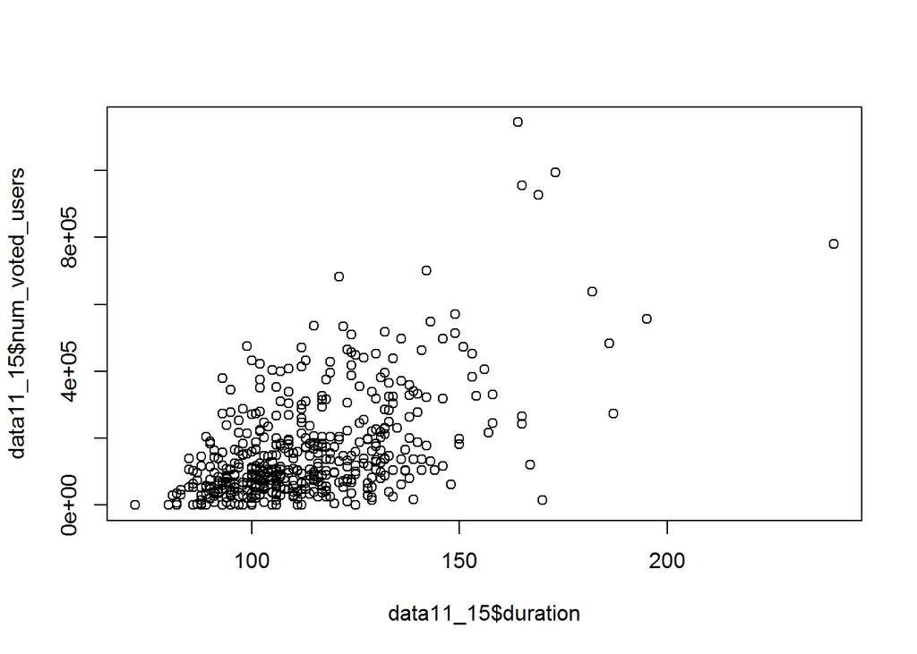

```r
plot(data11_15$duration, data11_15$num_voted_users)
```

The final criteria we consider is film genre. This is not straightforward, as a film can belong to more than one category (e.g. a sci-fi, action thriller). We adopt a count-based approach, based on the number of times a description appears, although this may introduce an added source of multicollinearity, which we attempt to limit by being selective over the categories included.

We subsequently notice that both family and sci-fi dummy genres are statistically significant. Bizarrely, we generate a negative coefficient for family films, implying these are likely to receive 79,000 less votes. Given the selection bias likely apparent with IMDB data, this may reflect the characteristics of those voting. For instance, is a 18-30 year old as inclined to render judgement on a family film (e.g. Finding Nemo) relative to a sequel in the Terminator franchise? Equally, is IMDB likely to find those with young families finding the time to vote for Finding Nemo on IMDB? Although a slight concern, the negative coefficient does appear logical.

What is more intriguing is the remaining genres all appear statistically insignificant. This probably reflects multicollinearity, so we begin refining the model to eliminate categories where this overlap is likely (equation 7). This appears to work, with our ${R}^{2}$ marginally increasing, along with the t-values of those genre variables that were already significant.

Overall, this model should mitigate the effect of statistical bias affecting our standard errors, and is intended to attain specification efficiency. However, it is likely our model violates our independently and identically distribution (“iid”) assumptions on our error terms, which is likely to be affected by an omitted variable(s). The high t-value attained on our intercept coefficient might be suggestive of this. We discuss overall model robustness further in section 5.

### Commercial: Box office ticket sales

|  | *Dependent variable:* |  |  |  |  |  |  |
| --- | --- | --- | --- | --- | --- | --- | --- |
|  | gross |  |  |  |  | log6_gross |  |
|  | (1) | (2) | (3) | (4) | (5) | (6) | (7) |
| budget | 1.042 | 1.184 | 1.062 | 1.089 | 1.080 | 0.178 | 0.177 |
|  | t = 20.629*** | t = 14.904*** | t = 18.098*** | t = 16.337*** | t = 16.302*** | t = 17.157*** | t = 20.042*** |
| actiondummy |  | -32,983,653.000 | -24,768,439.000 | -27,271,423.000 | -27,667,467.000 | -2,982,463.000 | -2,831,788.000 |
|  |  | t = -4.117*** | t = -3.361*** | t = -3.947*** | t = -4.008*** | t = -2.757*** | t = -2.660*** |
| adventuredummy |  | -11,096,435.000 |  |  |  |  |  |
|  |  | t = -1.180 |  |  |  |  |  |
| comedydummy |  | 11,857,608.000 | 8,243,329.000 | 10,393,520.000 | 10,776,015.000 | 2,809,055.000 | 2,865,055.000 |
|  |  | t = 1.668* | t = 1.292 | t = 1.724* | t = 1.790* | t = 2.977*** | t = 3.060*** |
| familydummy |  | 978,747.000 |  |  |  |  |  |
|  |  | t = 0.087 |  |  |  |  |  |
| fantasydummy |  | -12,168,300.000 |  |  |  |  |  |
|  |  | t = -1.362 |  |  |  |  |  |
| horrordummy |  | -4,042,222.000 |  |  |  |  |  |
|  |  | t = -0.396 |  |  |  |  |  |
| romancedummy |  | -4,188,287.000 |  |  |  |  |  |
|  |  | t = -0.482 |  |  |  |  |  |
| actor_oscars |  |  | 7,183,993.000 |  |  |  |  |
|  |  |  | t = 1.177 |  |  |  |  |
| dir_oscars |  |  | 5,014,701.000 |  |  |  |  |
|  |  |  | t = 0.386 |  |  |  |  |
| movie_oscars |  |  |  |  |  |  |  |
| director_occurence |  |  |  | 53,102,909.000 | 51,969,371.000 | 2,984,169.000 | 3,550,399.000 |
|  |  |  |  | t = 4.388*** | t = 4.308*** | t = 1.578 | t = 2.008** |
| actor1_occurence |  |  |  | -3,672,421.000 |  |  |  |
|  |  |  |  | t = -1.154 |  |  |  |
| actor2_occurence |  |  |  | 49,815,815.000 | 47,381,415.000 | 2,544,256.000 | 3,180,538.000 |
|  |  |  |  | t = 6.833*** | t = 6.788*** | t = 2.326** | t = 3.865*** |
| actor3_occurence |  |  |  | -13,982,780.000 | -13,159,804.000 | 404,222.900 |  |
|  |  |  |  | t = -4.332*** | t = -4.179*** | t = 0.819 |  |
| scifidummy |  | 20,871,344.000 | 24,010,155.000 | 16,904,515.000 | 16,843,887.000 | 1,049,757.000 |  |
|  |  | t = 2.392** | t = 2.837*** | t = 2.105** | t = 2.096** | t = 0.834 |  |
| thrillerdummy |  | 12,094,526.000 |  |  |  |  |  |
|  |  | t = 1.573 |  |  |  |  |  |
| Constant | 18,760,653.000 | 15,372,950.000 | 16,321,356.000 | -161,284,068.000 | -170,280,265.000 | 1,464,208.000 | 1,139,769.000 |
|  | t = 4.457*** | t = 2.377** | t = 3.148*** | t = -4.949*** | t = -5.380*** | t = 0.295 | t = 0.230 |
| Observations | 498 | 498 | 498 | 498 | 498 | 498 | 498 |
| R<sup>2</sup> | 0.462 | 0.493 | 0.486 | 0.538 | 0.537 | 0.489 | 0.487 |
| Adjusted R<sup>2</sup> | 0.461 | 0.482 | 0.480 | 0.531 | 0.530 | 0.481 | 0.482 |
| Residual Std. Error | 65,748,645.000 (df = 496) | 64,406,756.000 (df = 487) | 64,581,456.000 (df = 491) | 61,334,355.000 (df = 489) | 61,355,083.000 (df = 490) | 9,614,643.000 (df = 490) | 9,607,407.000 (df = 492) |
| F Statistic | 425.536*** (df = 1; 496) | 47.334*** (df = 10; 487) | 77.358*** (df = 6; 491) | 71.245*** (df = 8; 489) | 81.177*** (df = 7; 490) | 66.908*** (df = 7; 490) | 93.560*** (df = 5; 492) |
| *Note:* | p<0.1; p<0.05; p<0.01 |  |  |  |  |  |  |

|  | *Dependent variable:* |  |
| --- | --- | --- |
|  | log6_gross |  |
|  | (1) | (2) |
| budget | 0.177 | 0.099 |
|  | t = 20.042 | t = 4.152 |
| actiondummy | -2,831,788.000 | 595,658.500 |
|  | t = -2.660 | t = 0.175 |
| comedydummy | 2,865,055.000 | 3,515,727.000 |
|  | t = 3.060 | t = 1.283 |
| director_occurence | 3,550,399.000 | 1,386,804.000 |
|  | t = 2.008 | t = 0.524 |
| actor2_occurence | 3,180,538.000 | 906,495.100 |
|  | t = 3.865 | t = 0.472 |
| Constant | 1,139,769.000 | 17,928,414.000 |
|  | t = 0.230 | t = 1.638 |
| Observations | 498 | 37 |
| R<sup>2</sup> | 0.487 | 0.501 |
| Adjusted R<sup>2</sup> | 0.482 | 0.421 |
| Residual Std. Error | 9,607,407.000 (df = 492) | 7,898,479.000 (df = 31) |
| F Statistic | 93.560*** (df = 5; 492) | 6.226*** (df = 5; 31) |
| *Note:* | p<0.1; p<0.05; p<0.01 |  |

We follow a similar methodology above to translate social popularity into revenue generation by examining the impact of genres, actors, and budget. Contrary to the above, which reflects popularity on lagged variables, this model is intended to help hypothesise on future revenue performance.

We notice a discrepancy in film genres, with action and comedy films having a significant impact on revenues, the former having a negative effect. This may reflect the extra costs associated with stunts and special FX, which may not entirely be recouped from box office sales alone.

Our final model (equation 7) eliminates any insignificant variables, whilst also suggesting that the number of director and lead supporting actor appearances may be significant. We receive this cautiously, given the issues with actor variables mentioned above when appraising social metrics. We further observe this classification of lead and supporting actor may be subjective; one film in the Batman franchise (the “Dark Knight”) cites Christian Bale as Actor 2 despite playing the lead role of Batman. We suspect other instances, and thus consider this a more general measure of audience interest in participating actors.

We note a slight improvement in adjusted ${R}^{2}$ of 0.482 relative to equation 6. This benefits from a slight improvement in degrees of freedom, whilst equation 6 illustrates the impact of bias prior to adjusting our y-variable, given the change in significance and co-efficient sign on some variables (e.g. sci-fi dummy; actor 3 occurrence).

## Section 5: Robustness and Hypothesis Tests

### Robustness

Prior to backtesting our models, we want to get a sense of overall model robustness. We examine residual plots of our final models to help determine whether our iid assumptions on our error term are valid:

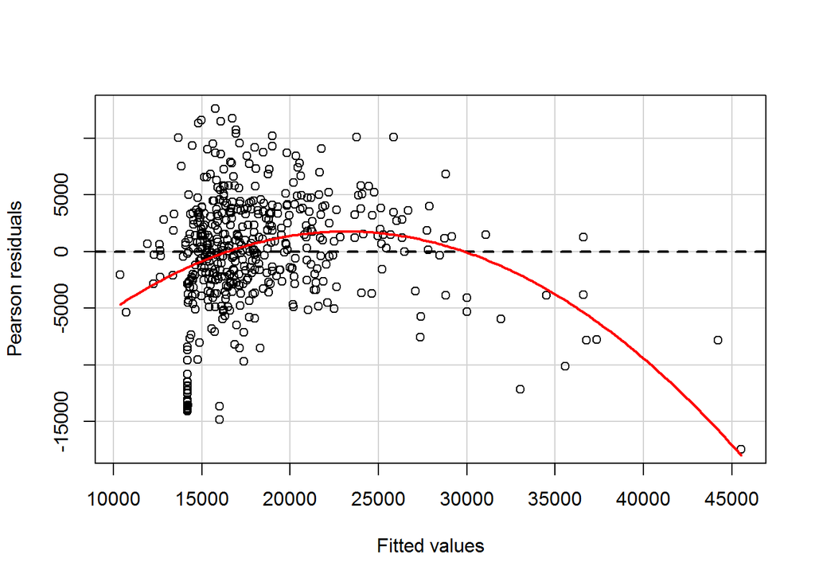

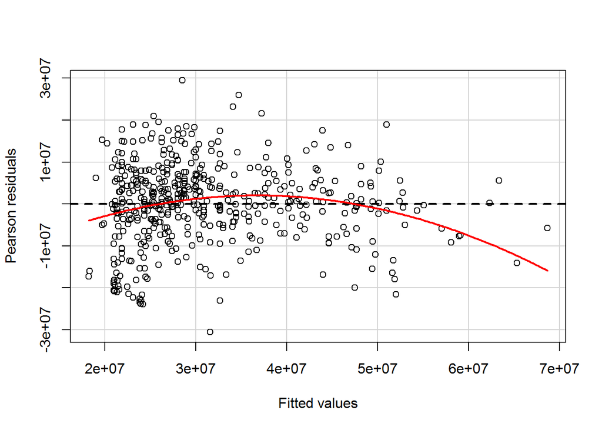

The trend line on both graphs indicates our iid assumptions are violated, with serial correlation present. This is likely attributable to other variables being omitted, along with potential error within some of our variable estimates. We would validate this with a Durbin-Watson test, although the residual plot is relatively self-evident.

We expect this to affect the accuracy of our standard error (and thus our t-values), increasing the likelihood of Type I and II errors. For the hypothesis tests that follow, we therefore must apply caution to any final result.

### Hypothesis tests

We start by regressing our 2011-15 model on our Jan-Aug 2016 dataset. This includes [37] data-points. With our log-transformed equations consistent with a normal distribution, we assume that a sample of this size should satisfy the central-limit theorem (ie. a sample > 30-35), enabling meaningful analysis; although we recognise further data-points would provide further comfort.

We obtain the following results for our IMDB votes and Revenue regressions:

|  | *Dependent variable:* |  |  |  |
| --- | --- | --- | --- | --- |
|  | log4numvoted_users |  | log6_gross |  |
|  | (1) | (2) | (3) | (4) |
| gross | 0.00005 | 0.00004 |  |  |
|  | t = 16.348*** | t = 5.715*** |  |  |
| actor_oscars | 2,152.065 | 811.284 |  |  |
|  | t = 4.560*** | t = 0.570 |  |  |
| familydummy | -3,848.250 | -1,938.968 |  |  |
|  | t = -5.442*** | t = -1.011 |  |  |
| scifidummy | 1,817.534 | 2,547.954 |  |  |
|  | t = 2.934*** | t = 1.680 |  |  |
| budget |  |  | 0.177 | 0.099 |
|  |  |  | t = 20.042*** | t = 4.152*** |
| actiondummy |  |  | -2,831,788.000 | 595,658.500 |
|  |  |  | t = -2.660*** | t = 0.175 |
| comedydummy |  |  | 2,865,055.000 | 3,515,727.000 |
|  |  |  | t = 3.060*** | t = 1.283 |
| director_occurence |  |  | 3,550,399.000 | 1,386,804.000 |
|  |  |  | t = 2.008** | t = 0.524 |
| actor2_occurence |  |  | 3,180,538.000 | 906,495.100 |
|  |  |  | t = 3.865*** | t = 0.472 |
| Constant | 14,166.470 | 8,360.113 | 1,139,769.000 | 17,928,414.000 |
|  | t = 44.474*** | t = 9.241*** | t = 0.230 | t = 1.638 |
| Observations | 498 | 37 | 498 | 37 |
| R<sup>2</sup> | 0.447 | 0.696 | 0.487 | 0.501 |
| Adjusted R<sup>2</sup> | 0.443 | 0.658 | 0.482 | 0.421 |
| Residual Std. Error | 4,987.700 (df = 493) | 3,384.724 (df = 32) | 9,607,407.000 (df = 492) | 7,898,479.000 (df = 31) |
| F Statistic | 99.692*** (df = 4; 493) | 18.283*** (df = 4; 32) | 93.560*** (df = 5; 492) | 6.226*** (df = 5; 31) |
| *Note:* | p<0.1; p<0.05; p<0.01 |  |  |  |

```
##
##  F test to compare two variances
##
## data:  usereg10 and usereg11
## F = 2.1715, num df = 493, denom df = 32, p-value = 0.008986
## alternative hypothesis: true ratio of variances is not equal to 1
## 95 percent confidence interval:
##  1.226798 3.423952
## sample estimates:
## ratio of variances
##           2.171471
```

```
##
##  F test to compare two variances
##
## data:  rev_mod7 and rev_mod8
## F = 1.4795, num df = 492, denom df = 31, p-value = 0.1825
## alternative hypothesis: true ratio of variances is not equal to 1
## 95 percent confidence interval:
##  0.8275493 2.3469295
## sample estimates:
## ratio of variances
##           1.479536
```

We separately examine what our parameter coefficients return across both models. We formulate our hypothesis as follows:

$$H_0 : \beta_{(i\ , \ 11-15)} = \beta_{(i\ ,\ 16)} \ \ \ or \ \ \ \ \beta_{(i\ ,\ 11-15)} - \beta_{(i\ ,\ 16)} = 0$$
$$H_1 : \beta_{(i\ , \ 11-15)} \neq \beta_{(i\ ,\ 16)} \ \ \ or \ \ \ \ \beta_{(i\ ,\ 11-15)} - \beta_{(i\ ,\ 16)} \neq 0$$

First, we look at results of the Z test for the social popularity model:

Z Test for co-efficient for Social Popularity Model

[output not shown]

One reason why the actor_oscars and familydummy variables are not significant for 2016 data is that the current 2016 dataset is too small (only 37 observations while there are 4 independent variables) and the two datasets on these variables are not consistent based on the t test and F test we conducted previously.

However, the signs of all coefficients in the 2016 model are the same as 2011-2015 model, which could prove the general correctness of our model.

Second, we look at the commercial success model:

Z Test for co-efficient for Commercial Success Model

| name | z_statistics | p_value |
| --- | --- | --- |
| budget | 0.7918 | 0.4296 |
| actiondummy | -5.7540 | 0.0000 |
| comedydummy | -0.1851 | 0.8572 |
| director_occurence | 1.5601 | 0.1188 |
| actor2_occurence | 2.5086 | 0.0120 |

The left column in the regression table stands for the model that was built based on 2011 - 2015 data, and the right one for year 2016. Only the budget variable is highly significant.

The z-test for the coefficients, however, shows a slightly more positive result. The coefficients of budget, comedy dummy and director_occurrence variables do not show much difference on dataset 2011-15 and dataset 2016.

## Section 6: Limitations

Besides the commentary above on robustness, we recognise there are several issues within our data. The original sample, though randomly generated, does not facilitate a more comprehensive assessment of Hollywood and non-Hollywood film statistics over the time horizon. It may also have resulted in the skewness observed within our datasets.

Being unable to source separate details on financial characteristics on each film has further hindered this process, whilst limiting our ability to investigate the full value chain. Examples of other financial characteristics we wanted to appraise include:

- A breakdown of budget expenses - marketing: understanding spend to promote films prior to release, and upon the immediate release of a film. This includes the amount spent on social media platforms, relative to conventional mediums (e.g. newspaper ads; TV commercials, etc), to better understand how this affects the perception of popularity and contributes to revenues
- A breakdown of budget expenses - pre / post production costs: including salaries for the leading actor(s) / supporting actors. This would better approximate the value of an actor, including their perception of popularity, representing a more apt variable relative to counting the number of actor occurences between 2011-16 (see below).
- DVD, in-film advertising, merchandise sales, and any cash subsidies: To gauge financial success, understanding the contribution of other revenue streams to determining overall pre-tax returns on investment. This also applies to any direct government incentives (e.g. subsidies) to support the production of films. This data is likely to boost the significance of our ROI estimator.

We also recognise that our attempts to quantify film-specific estimators could be further improved. Qualifying the popularity of actors by virtue of their appearance within our random sample alone is insufficient (relative to their overall appearances as a lead or supporting actor). This was partly mitigated by number of Oscars, although left a sufficient gap between well known actors and those that have yet to receive an award. Accounting for this may have reduced the level of serial correlation evident within our residual plots, with film preferences unlikely to be independent between each year (e.g. a favoured actor in one year is likely to remain so in the following period).

Another limitation was our inability to specify a single genre for each film. Our dataset classified each film across multiple genres, resulting in our dummy variables potentially lacking in sufficient power from diluting their relevance. It was thus a surprise to learn that family films were statistically more significant than action, comedy, romance, or thrillers, which were all well represented within our sample. We may thus have introduced error into our residual, which we would seek to correct in future from either a third party classification source, and / or from performing key-word count searches on film synopses.

## Section 7: Conclusions and next steps

In terms of developing our study, we would like to understand how these findings apply to arthouse films.

## Appendix 1 - Source of dataset

The raw dataset comes from Kaggle website[^4], the Dataset section. It includes:

Variables

| Variable_No.1.14. | Variable_name_full.1.14. | Variable_No.15.28. | Variable_name_full.15.28. |
| --- | --- | --- | --- |
| 1 | actor_1_facebook_likes | 15 | duration |
| 2 | actor_1_name | 16 | facenumber_in_poster |
| 3 | actor_2_facebook_likes | 17 | genres |
| 4 | actor_2_name | 18 | gross |
| 5 | actor_3_facebook_likes | 19 | imdb_score |
| 6 | actor_3_name | 20 | language |
| 7 | aspect_ratio | 21 | movie_facebook_likes |
| 8 | budget | 22 | movie_imdb_link |
| 9 | cast_total_facebook_likes | 23 | movie_title |
| 10 | color | 24 | num_critic_for_reviews |
| 11 | content_rating | 25 | num_user_for_reviews |
| 12 | country | 26 | num_voted_users |
| 13 | director_facebook_likes | 27 | plot_keywords |
| 14 | director_name | 28 | title_year |

The steps the data set was acquired are as follows:

- **Step 1:** Generate a JSON file including a list of 5,000 movie titles and budgets from The Numbers website[^5]. The budgets of scraped movies, as the index value that is used to extract movie title, are ranged from over US$ 425,000,000 to only US$ 800,000 which ensures the dataset covers the most mainstream movies in the market.
- **Step 2:** Use the movie title in the JSON file to search from IMDB website for the real IMDB movie links and create a JSON file containing movie-link pairs.
- **Step 3:** Send HTTP request to each specific movie page with the movie-link pairs, and scrape 5,000+ IMDB movie information.
- **Step 4:** Parse and clean the aggregated data, convert into valid format and generate the final CSV table.

Please note that due to the restriction on IMDB website, all the facebook likes data were scraped directly from the Facebook website[^6] in August 2016.

The Kaggle website made some minor changes in October 2017 with the opensource dataset per a DMCA takedown request from IMDB, however, all the data our analysis based on are the original IMDB data. The removed columns are:

Variables

| Variable_No | Variables |
| --- | --- |
| 1 | actor_1_facebook_likes |
| 2 | actor_2_facebook_likes |
| 3 | actor_3_facebook_likes |
| 4 | aspect_ratio |
| 5 | cast_total_facebook_likes |
| 6 | color |
| 7 | content_rating |
| 8 | director_facebook_likes |
| 9 | facenumber_in_poster |
| 10 | movie_facebook_likes |
| 11 | movie_imdb_link |
| 12 | num_critic_for_reviews |
| 13 | num_user_for_reviews |

## Appendix 2 - Data Cleaning Methodology

1. **IMDB Movie Dataset:** The raw dataset is the IMDB information about the movies released between 1916 and 2016 (August), scrapted by Kaggle user chuansun76 from IMDB website. It contains 28 variables and 5043 observations. These variables include information about the movie performance on the box office, the actor(s) name, direcor(s) names, movie genre, movie facebook likes and more.
   - **Step 1 - Cleaning up inconsistent observations:** The raw dataset contained a lot of inconsistencies, namely ‘NA’ or Blank values for several observations. In order to obtain a consistent data to perform analysis on, we *removed all the observations with any NA or blank values*.
   - **Step 2 - Removing duplicate values:** We observed that the dataset contained duplicate observations, which were also removed.
   - **Step 3 - Limiting dataset by time frame and country:** The money-related variables in the dataset would be influenced by inflation, and the consistency of social presence variables is heavily reliant to the social media popularity. Therefore, it is reasonable to *narrow down the dataset timeframe into 2011 - 2016 (August)*. Besides, there are certain limit[^7] on the types of box office currency, so we only *focus on US movie market* to avoid the influence of exchange rate fluctuation.
   - **Step 4 - Segregating the movie genres:** The dataset contained the movie genres in the form of a single string, with every genre of the movie, delimited by a ‘|’ symbol. In order to get the actual genres separated and ready to use, we used created flags in order to check whether the movie is of a particular genre. For example: the ‘action_genre’ column will have a 1 value for an observation, if it is an action movie.
   - **Step 5 - Calculating the number of occurences of each actor/director:** Another interesting variable that we expect to be of significance to our analysis was the number of times an actor/director has showed up in our dataset. That data would allow us to possibly find interesting points on how an actor/director can impact a movie’s performance/success. Thus, we added variables/columns with the *number of occurences for actors and directors*.
   - **Step 6 - Calculating the movie ROI:** We add another variable, ‘movie_roi’ which contains the *return on investment for each movie*. This will help us in our analysis.
   - **Step 7 - Selecting only the required columns:** The raw dataset consisted of 28 variables, many of which are not required in our analyses. Thus, we remove the unwanted columns and keep only the data that is specific to our analysis. In the process we reduce the size of the dataset leading to better performance. For more details please see data description below.

After deleting the variables that have N/A values and that are less relevant to the aim of our report, our final variables (in alphabetical order) are:

Variables

| Variable_name | Explanation |
| --- | --- |
| actor_1_name | Main actor/actress 1. |
| actor_2_name | Main actor/actress 2. |
| actor_3_name | Main actor/actress 3. |
| actor1_occurence | The number of actor/actress 1’s occurence in the dataset. |
| actor2_occurence | The number of actor/actress 2’s occurence in the dataset. |
| actor3_occurence | The number of actor/actress 3’s occurence in the dataset. |
| actor_oscars | The sum of the Oscar Award all actor/actress have earned. |
| budget | Total budget for the movie in US dollar. Some numbers are estimated; they are based on media reports and are often supplied by sources close to the production. |
| director_name | Main director’s name. |
| director_occurence | The number of the main director’s occurence in the dataset. |
| dir_oscars | The sum of the Oscar Award main director has earned so far. |
| genre dummy variables | The dummy variables of the movie’s genre. 1 stands for the movie belongs to this genre. The dummies include: actiondummy, adventuredummy, animationdummy, biographydummy, comedydummy, crimedummy, docum… |
| duration | Length of the movie. |
| genres | Genres of the movie. The movie could be multi-genres. |
| gross | Gross box office earnings of the movie in US dollar. |
| imdb_score | IMDB average score (out of 10). |
| movie_facebook_likes | Total likes of the movie’s facebook page (up to Aug 2016). |
| movie_oscars | The sum of the Oscard Award this movie has earned so far. |
| movie_title | Movie’s title. |
| num_critic_for_reviews | Number of critics who wrote reviews for the movie. |
| num_user_for_reviews | Number of IMDB users who wrote reviews for the movie. |
| num_voted_users | Number of IMDB users who voted for the movie rating. |
| return/movie_roi | Gross divided by budget, rounded to 2 decimal places. |
| sum_actor_occurence | The sum of all actor/actress occurence in the dataset. |
| title_year | The year the movie released. |

The cleaned movie dataset now has 535 obseravations over 39 variables. Please note that there are 21 variables which are genre indicators, and 4 are occurence variables.

2. **Oscar winners dataset:** The raw dataset of awards contained 2321 observations over 4 variables. This database consisted the nominees and winners of the Academy Awards (or Oscars) ever since its inception, i.e. from 1927 to 2015.
   - **Step 1 - Cleaning up inconsistent observations:** The raw dataset contains some inconsistent observations where the names of the winner and the film were placed in the incorrect column. Since this was the case for the initial few records only, we ignored this and copied the values in the ‘film’ column to the ‘names’ column.
   - **Step 2 - Limiting dataset:** The dataset included both nominess and winner from every category. We were interested in collecting data about the actors, directors, and the best picture winners only in order to see how that impacts the success of a movie. Therefore, we *excluded the nomiees and only kept the winners for the awards* related to Best Actor/Actress in a Lead/Supporting role, Best Director and Best Picutre.
   - **Step 3 - Counting the awards:** In order to get the data of the number of wins for each individual, we introduced a new column ‘num_wins’ which counted the *number of occurences of a name in the winners list*. Using this data makes sense as in order to assess the impact of this on a movies popularity/success.
   - **Step 4 - Selecting the required columns:** The raw dataset contains 4 variables, and a count column, out of which only the ‘count’ and ‘name’ column is required for our analysis. Thus we select only a small subset of the raw data for our analysis.

The cleaned awards data now has 434 observations over 2 variables. This data will come handy to check which movies/actors/directors have oscar(s) to their name(s) and how that impacts the success of a movie.

3. **Final (Cumulative) Dataset:** In order to get the final working database, we combine the information from the two cleaned datasets.
   - **Step 1 - Summarizing the datasets:** We need to get the number of award wins for actors, directors, and movie for each observation in the into the IMDB movie dataset, from the ‘Oscar winners dataset’. We do this by introducing new variables that capture *the count of oscars for each actor, director, and movie for each observation*.
   - **Step 2 - Dividing the final data into two datasets:** The aim of our analysis is to create a model that can predict the success of a hollywood movie. To achieve that, we will build a regression model using the data of movies from 2011 to 2015 and then test the consistency of the data for the movies in 2016. This will provide a clear indication of how our model fits with current movies, and a direction of further development. Thus we *create two subsets of the final data, one for data of movies from 2011 to 2015 and the other with the data of movies for 2016*.

## Appendix 3 - Boxplots and Density graphs

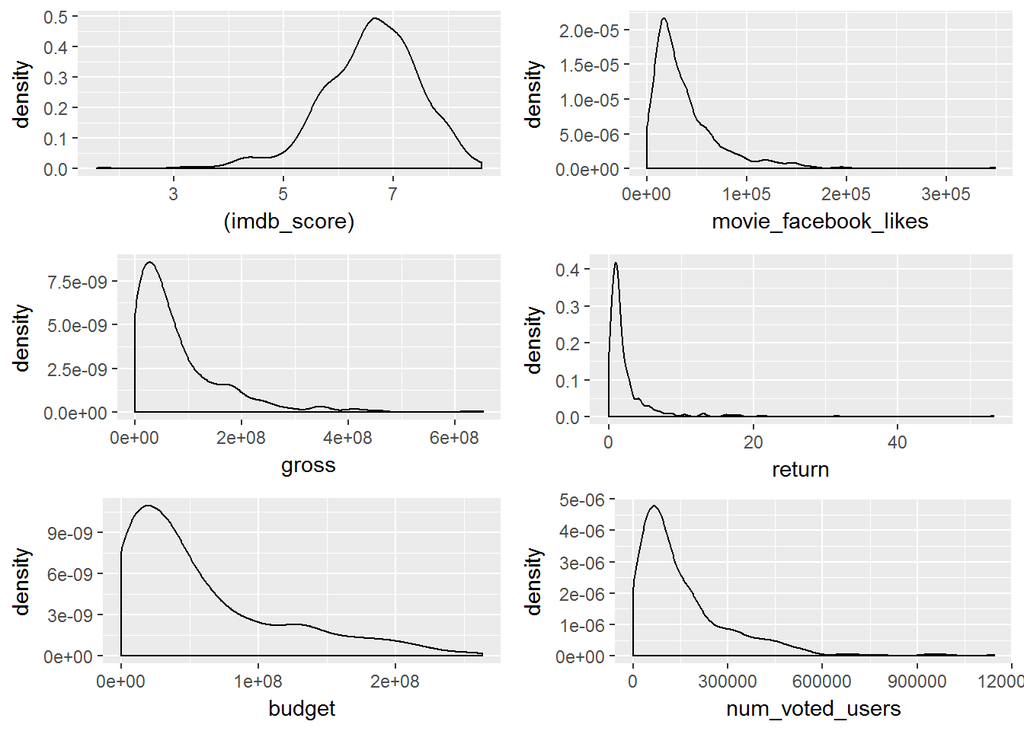

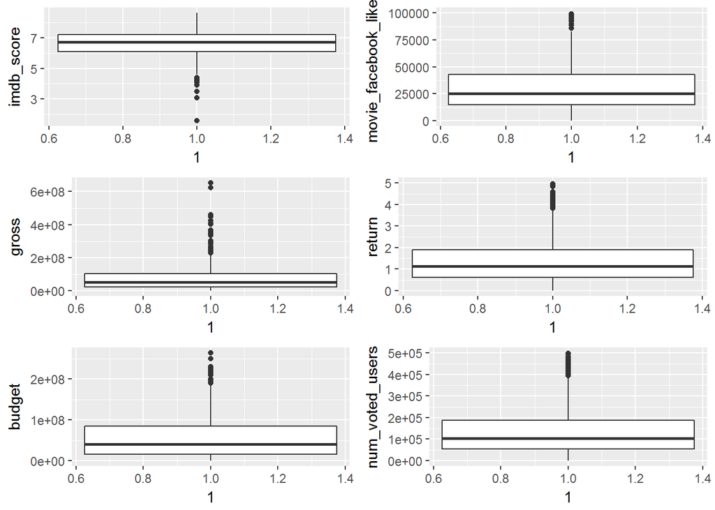

## Bibliography and references

We have made reference to various forums on coding best-practices, notably including Stackoverflow.com, and other relevant sources of R studio information available online. These have been cited during the main document, where they have been specific to our study, or represent the application of coding practices not within the Maths and Statistics Foundations for Analytics module. We have not referenced general R studio packages applied within this module (e.g. dplyr; stargazer; etc).

We obtained the original dataset, in conjunction with information on Oscar academy awards, from the following websites: https://www.kaggle.com/tmdb/tmdb-movie-metadata/data https://www.kaggle.com/theacademy/academy-awards

In terms of documents we have referenced:

[1-2] “Film industry in the US”, Statista, Dossier (2016) https://www.statista.com/study/11472/film-industry-in-the-united-states-statista-dossier/ [3] “The Interview”, Wikipedia page (2017) https://en.wikipedia.org/wiki/The_Interview#Pre-release_reaction [4] “How to tell the greatness of a movie before it is released in cinema”, NYC Data Science Academy, Chuansun76 (2016) https://chuansun76.com/2016/09/23/how-to-tell-the-greatness-of-a-movie-before-it-is-released-in-cinema/